# Introdução à economia

Aula 27 - Macroeconomia aberta: conceitos básicos

Prof. Roberto de Freitas Neder

## Aula 27: roteiro

**Macroeconomia aberta: conceitos básicos** · Mankiw, capítulo 31 · UnB

- Comércio e integração
- Ativos e fluxos de capitais
- Poupança e investimento
- Contas externas brasileiras
- Câmbio nominal e real
- O euro
- Arbitragem e PPC
- Limites e aplicações da PPC
- Conclusão
- Exercícios de concursos públicos

Use as setas para mudar de slide. Exemplos numéricos são hipotéticos, salvo indicação expressa. A última página reúne as questões, com rolagem e respostas comentadas que se abrem ao clicar.

## 01 - Uma economia conectada ao mundo

Uma **economia aberta** troca bens, serviços e ativos com outros países. Uma economia fechada é a referência teórica sem essas transações.

| Duas conexões | O que circula | Exemplo brasileiro |
| --- | --- | --- |
| Comércio internacional | Bens e serviços | Exportação de café; importação de máquinas; turismo |
| Relações financeiras | Direitos sobre rendas e patrimônios | Compra de ações estrangeiras; investimento de uma empresa estrangeira no Brasil |

**Pergunta do capítulo:** como comércio, poupança, investimento e câmbio se relacionam?

As vantagens comparativas, estudadas em microeconomia, ajudam a explicar as trocas. Aqui observamos seus **resultados agregados** e as relações com o financiamento da economia.

Fonte: Mankiw, 8ª edição, capítulo 31, *Open-Economy Macroeconomics: Basic Concepts*, pp. 653 a 675.

← Menu

## 02 - Exportações, importações e saldo externo

**Exportações ($X$):** bens e serviços produzidos internamente e vendidos ao exterior. **Importações ($M$):** bens e serviços produzidos no exterior e comprados internamente.

$$NX=X-M$$

| Resultado | Nome no modelo do capítulo | Exemplo hipotético |
| --- | --- | --- |
| $X>M$ | Superávit comercial | $X=300$, $M=250$: $NX=50$ |
| $X<M$ | Déficit comercial | $X=250$, $M=300$: $NX=-50$ |
| $X=M$ | Comércio equilibrado | Saldo zero, mesmo com muitas trocas |

**Atenção ao PIB:** subtrair importações evita contar produção estrangeira já incluída em $C$, $I$ ou $G$. Isso não significa que cada importação, isoladamente, destrua produção nacional.

← Menu

## 03 - Por que o comércio cresce e muda?

As trocas respondem aos **preços relativos**, às rendas interna e externa, aos gostos dos consumidores, ao câmbio, aos custos de transporte e às políticas comerciais.

- **Integração:** transporte mais barato, comunicação digital e bens mais fáceis de transportar aproximam mercados. O livro ilustra a maior abertura dos EUA ao longo do século XX.
- **Política comercial:** tarifas, quotas e acordos alteram o acesso a mercados. Normas ambientais, trabalhistas e de propriedade intelectual também importam.
- **Distribuição:** os ganhos agregados do comércio podem coexistir com perdas de trabalhadores e setores específicos. Ajustamento e proteção social têm custos e escolhas.

**Exemplo:** maior renda no exterior pode elevar a demanda por produtos brasileiros; maior renda no Brasil pode ampliar as importações. Tecnologia e política influenciam os dois fluxos.

← Menu

## 04 - Investimento direto e investimento em carteira

As transações financeiras permitem que a poupança de um país financie atividades e ativos em outro.

| Modalidade | Característica | Exemplo |
| --- | --- | --- |
| Investimento direto | Participação duradoura, com influência relevante na gestão | Empresa estrangeira instala ou adquire uma unidade no Brasil |
| Investimento em carteira | Compra de títulos e participações sem a relação de investimento direto | Residente brasileiro compra um título público estrangeiro |

O critério das contas externas é a **residência econômica**, e não o passaporte do investidor.

**Duas ideias diferentes:** comprar uma ação é investimento financeiro; $I$, no PIB, representa formação de capital, incluindo estoques. A compra de uma ação já existente não é, por si, nova produção de máquinas ou instalações.

← Menu

## 05 - Saída líquida de capitais: significado e sinais

O livro chama de **saída líquida de capitais ($NCO$)** a aquisição líquida de ativos estrangeiros por residentes menos a aquisição líquida de ativos domésticos por não residentes.

| Sinal | Interpretação |
| --- | --- |
| $NCO>0$ | O país aplica, em termos líquidos, recursos no exterior |
| $NCO<0$ | O país recebe, em termos líquidos, financiamento do exterior |
| $NCO=0$ | Entradas e saídas se compensam; os fluxos brutos podem ser grandes |

**O que influencia os fluxos?** Retornos reais esperados, risco econômico e político, expectativas sobre o câmbio e regras para a participação estrangeira.

Uma empresa brasileira investir fora aumenta a saída; um estrangeiro adquirir um ativo brasileiro aumenta a entrada. O resultado líquido reúne os dois movimentos.

← Menu

## 06 - Por que exportações líquidas e capitais se igualam?

**No modelo simplificado do capítulo**, sem rendas e transferências internacionais líquidas:

$$NX=NCO$$

Uma empresa brasileira exporta software por **US$ 1.000**. O que acontece com o recebimento?

| Destino dos dólares | Resultado agregado do exemplo |
| --- | --- |
| Mantidos em uma conta no exterior | A exportação corresponde à aquisição de um ativo externo |
| Usados para importar um computador | Exportação e importação se compensam; $NX=NCO=0$ |
| Vendidos a um banco brasileiro | O ativo passa a outro residente; a relação agregada permanece |

**Intuição:** vender mais bens e serviços do que se compra gera aquisição líquida de direitos sobre o exterior. Comprar mais exige financiamento líquido externo.

← Menu

## 07 - Da identidade do PIB à poupança

Partimos da identidade da despesa e definimos a poupança nacional no modelo:

$$\begin{aligned}
Y&=C+I+G+NX\\
S&=Y-C-G\\
S&=I+NX=I+NCO
\end{aligned}$$

Com $T$ representando impostos líquidos de transferências, a decomposição didática é:

$$S_p=Y-T-C,\qquad S_g=T-G,\qquad S=S_p+S_g$$

**Leitura econômica:** a poupança nacional financia o investimento interno e a aquisição líquida de ativos no exterior. Numa economia fechada, $NCO=0$ e $S=I$.

Aqui, $G$ segue a convenção simplificada do livro. Não equivale a todas as despesas do orçamento público.

← Menu

## 08 - Três situações e a poupança externa

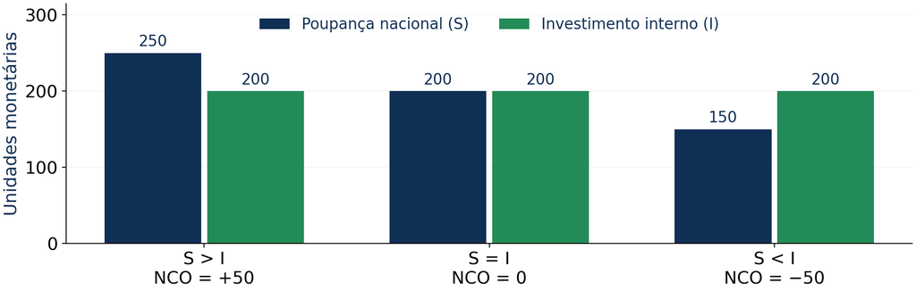

Poupança nacional e investimento interno em três economias hipotéticas

$$S_{ext}=-NCO\qquad\Rightarrow\qquad I=S_p+S_g+S_{ext}$$

**Se $S<I$:** entra financiamento líquido e $S_{ext}>0$. **Se $S>I$:** o país financia o exterior e $S_{ext}<0$.

Fonte: elaboração didática. Valores hipotéticos, em unidades monetárias; hipóteses do modelo simplificado de Mankiw. Retoma a decomposição estudada na Aula 17.

← Menu

## 09 - Um déficit externo é necessariamente ruim?

O saldo, sozinho, não informa a qualidade do processo econômico. É preciso investigar **por que** o país recebe financiamento e **como** utiliza os recursos.

| Caso discutido no livro: EUA | Leitura econômica |
| --- | --- |
| Anos 1980 | Queda da poupança nacional ampliou a necessidade de financiamento externo |
| Anos 1990 | Expansão do investimento também contribuiu para déficits externos |
| Anos 2000 até 2015 | Poupança e investimento oscilaram; o saldo não teve uma única causa |

Financiar capacidade produtiva pode elevar a renda futura. Financiar gastos sem retorno suficiente pode ampliar a vulnerabilidade.

**Perguntas relevantes:** em que se investe? A dívida está em qual moeda? Quais são seus prazos? Há capacidade futura de pagamento? Um superávit também pode refletir investimento interno deprimido.

← Menu

## 10 - Do modelo às contas externas brasileiras

No capítulo, $NX$ inclui **bens e serviços**. Nas estatísticas brasileiras, “balança comercial” normalmente designa apenas os bens.

$$CC=NX+RLP+RLS$$

$CC$: saldo em transações correntes; $RLP$: renda primária líquida recebida, como juros e lucros; $RLS$: renda secundária líquida recebida, como transferências correntes.

| Conta | Registra, por exemplo |
| --- | --- |
| Corrente | Bens, serviços, rendas e transferências correntes |
| Capital | Transferências de capital e ativos não financeiros não produzidos |
| Financeira | Investimento direto, carteira, empréstimos e reservas |

Incluindo rendas e transferências, **$S_n-I=CC$** e **$S_{ext}=-CC$**, com poupança nacional e investimento definidos de modo consistente. Portanto, não se deve aplicar $NX=NCO$ às estatísticas completas sem ajustar as hipóteses.

Fonte: [Banco Central, metodologia do balanço de pagamentos, BPM6](https://www.bcb.gov.br/content/estatisticas/notas_metodologicas/balanco_pagamentos/bpm6/nm1bpm6p.pdf).

← Menu

## 11 - Câmbio nominal: o preço de uma moeda

Adotaremos a cotação usual no Brasil:

$$E=\frac{\text{reais}}{\text{dólar}}$$

**Exemplo hipotético:** $E=5$ significa que US$ 1 custa R$ 5. Uma compra de US$ 100 exige R$ 500, antes de tarifas e tributos.

| Convenção | Exemplo | Relação |
| --- | --- | --- |
| Aula: reais por dólar | $E=5$ | Preço do dólar em reais |
| Livro: moeda estrangeira por unidade doméstica | $e=0{,}20$ dólar por real | $e=1/E$ |

**Primeiro leia a unidade, depois interprete a mudança.** Um índice de câmbio efetivo combina várias moedas de parceiros comerciais; não é apenas a cotação bilateral do dólar.

← Menu

## 12 - Valorização e desvalorização do real

Mantidos os preços nas respectivas moedas:

| Cotação $E$ | O que acontece com o real? | Compra de US$ 100 |
| --- | --- | --- |
| De 5 para 6 | Desvaloriza: compra menos dólares | De R$ 500 para R$ 600 |
| De 5 para 4 | Valoriza: compra mais dólares | De R$ 500 para R$ 400 |

**Real mais fraco:** encarece importações, viagens e obrigações em dólar; pode favorecer receitas de exportação em reais. Os efeitos variam conforme custos importados e contratos.

Maior demanda por dólares tende a elevar $E$; maior oferta tende a reduzi-lo, tudo o mais constante. Uma compra de divisas pelo BCB pressiona nessa primeira direção.

O repasse aos preços e a resposta das quantidades não são necessariamente imediatos nem completos.

← Menu

## 13 - Câmbio real: o preço relativo dos bens

Comparamos uma cesta estrangeira, convertida em reais, com uma cesta doméstica comparável:

$$q=\frac{EP^*}{P}$$

$P^*$ é o preço estrangeiro em dólares; $P$, o preço doméstico em reais. **$EP^*$** é o preço estrangeiro já convertido em reais.

| Movimento de $q$ | Interpretação, nesta convenção |
| --- | --- |
| $q$ aumenta | Depreciação real: bens estrangeiros ficam relativamente mais caros |
| $q$ diminui | Apreciação real: bens estrangeiros ficam relativamente mais baratos |

No livro, $\varepsilon=eP/P^*=1/q$. As setas se invertem porque a cotação se inverte; o fenômeno econômico é o mesmo.

← Menu

## 14 - Um exemplo para enxergar o câmbio real

Suponha um pacote de arroz comparável: **R$ 100 no Brasil** e **US$ 20 no exterior**.

| Situação hipotética | Preço estrangeiro em reais | Câmbio real |
| --- | --- | --- |
| $E=5$ | $5\times20=100$ | $q=100/100=1$ |
| $E=6$ | $6\times20=120$ | $q=120/100=1{,}2$ |

No segundo caso, o pacote estrangeiro custa o equivalente a **1,2 pacote brasileiro**. O produto brasileiro ficou relativamente mais barato.

Esse preço relativo pode estimular exportações e a substituição de importações. A reação depende de capacidade produtiva, qualidade, contratos e possibilidade de substituição entre bens.

Para a economia inteira, usam-se índices de preços de cestas amplas, e não apenas o preço do arroz.

← Menu

## 15 - O dólar pode subir sem depreciação real

**Exemplo:** o dólar sobe 10%, mas o preço doméstico também sobe 10%. O preço estrangeiro permanece constante.

| Variável | Antes | Depois |
| --- | --- | --- |
| $E$, reais por dólar | 5 | 5,50 |
| $P$, preço doméstico em reais | 100 | 110 |
| $P^*$, preço estrangeiro em dólares | 20 | 20 |
| $q=EP^*/P$ | 1 | 1 |

Houve desvalorização **nominal**, mas o preço relativo dos bens não mudou. Em taxas de variação pequenas:

$$\underbrace{g_q}_{\text{variação real}}\approx\underbrace{g_E}_{\text{variação nominal}}+\pi^*-\pi$$

← Menu

## 16 - O euro: comércio com uma moeda comum

O euro foi lançado como moeda em **1999**; notas e moedas entraram em circulação em **2002**. Os países participantes compartilham a política monetária conduzida pelo Eurosistema.

| Benefícios possíveis | Custos e dificuldades |
| --- | --- |
| Menores custos de conversão entre participantes | Perda de política monetária nacional autônoma |
| Comparação de preços mais simples | Uma taxa de juros comum pode atender mal a situações diferentes |
| Ausência de oscilação cambial nominal entre membros | Ajustar choques passa a depender mais de preços, salários, mobilidade e política fiscal |

**Conexão com o capítulo:** com câmbio nominal fixo entre os participantes, diferenças de inflação ainda alteram seus preços relativos e sua competitividade.

Fonte: Mankiw, quadro sobre o euro; [Banco Central Europeu, origem da moeda](https://www.ecb.europa.eu/euro/intro/html/index.en.html).

← Menu

## 17 - Lei do preço único e arbitragem

Um bem idêntico, negociável entre mercados sem barreiras ou custos relevantes, tende a ter o **mesmo preço quando expresso na mesma moeda**.

**Exemplo hipotético:** um produto custa R$ 100 no Brasil e US$ 30 fora. Com $E=5$, o preço estrangeiro equivale a R$ 150.

1. Comprar no Brasil e revender no exterior oferece uma diferença bruta de R$ 50.
2. A compra adicional tende a elevar o preço no mercado barato; a oferta adicional tende a reduzi-lo no mercado caro.
3. Essa **arbitragem** pressiona os preços convertidos a convergirem.

O mecanismo depende de poder transportar e revender o produto. Frete, impostos, barreiras e diferenças de qualidade podem eliminar a oportunidade.

← Menu

## 18 - Paridade do poder de compra: versão absoluta

A **PPC** estende a lógica do preço único a uma cesta: uma unidade monetária deveria comprar a mesma quantidade de bens nos diferentes países, após a conversão.

$$P=EP^*\qquad\Rightarrow\qquad E=\frac{P}{P^*}\quad\text{e}\quad q=1$$

**Exemplo hipotético:** a mesma cesta custa R$ 500 no Brasil e US$ 100 no exterior. A cotação de paridade seria **R$ 5 por dólar**.

Se o poder de compra do real cai internamente em relação ao do dólar, a PPC prevê uma desvalorização nominal do real.

**Cuidado:** $q=1$ pressupõe preços comparáveis da mesma cesta. Índices estatísticos com bases arbitrárias não permitem concluir que uma moeda está sobrevalorizada apenas porque um índice está acima de 1 ou de 100.

← Menu

## 19 - Inflação e câmbio: versão relativa da PPC

A versão relativa relaciona a **variação do câmbio nominal** à diferença de inflação entre os países, mantendo o câmbio real constante:

$$\frac{E_1}{E_0}=\frac{1+\pi}{1+\pi^*}\qquad\Rightarrow\qquad g_E\approx\pi-\pi^*$$

**Exemplo hipotético:** inflação brasileira de 10% e externa de 2%.

$$g_E=\frac{1{,}10}{1{,}02}-1\approx7{,}84\%$$

A aproximação seria **8% de desvalorização nominal**. Maior inflação doméstica exige mais reais por dólar para preservar o mesmo câmbio real.

No raciocínio clássico das Aulas 25 e 26, expansão monetária persistentemente superior ao crescimento real tende a gerar inflação e, pela PPC, depreciação nominal. É uma relação de longo prazo, condicionada às hipóteses do modelo.

← Menu

## 20 - Hiperinflação: preços, moeda e câmbio

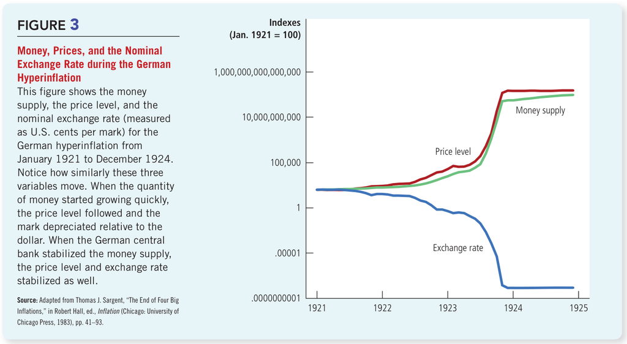

Moeda, preços e valor externo do marco na hiperinflação alemã, 1921 a 1924

Na Alemanha dos anos 1920, moeda e preços dispararam, enquanto o valor do marco em **centavos de dólar por marco** caiu. Observe a cotação inversa à usada nesta aula e a **escala logarítmica**.

O caso ilustra a associação entre perda de poder de compra interno e externo. O gráfico, isoladamente, não identifica toda a causalidade da crise.

Fonte: Mankiw, 8ª edição, cap. 31, figura 3, p. 670; reprodução do gráfico do arquivo fornecido, com fonte original indicada na figura.

← Menu

## 21 - Por que a PPC não é uma regra exata?

| Limitação | Exemplo e consequência |
| --- | --- |
| Bens e serviços não comercializáveis | Um corte de cabelo não pode ser transportado para arbitragem |
| Custos e barreiras ao comércio | Fretes, tributos e tarifas sustentam diferenças de preços |
| Substitutos imperfeitos | Marcas, qualidade e preferências permitem preços distintos |
| Cestas e estruturas diferentes | Pesos de bens, produtividade e padrões de consumo variam |
| Movimentos financeiros | Juros, risco e expectativas podem mover o câmbio rapidamente |

A PPC oferece uma **referência de longo prazo**, especialmente útil para pensar grandes diferenças de inflação. Não prevê com precisão a cotação de amanhã nem garante igualdade contínua entre preços nacionais.

No curto prazo, o câmbio pode variar muito mais depressa que os preços dos bens.

← Menu

## 22 - O “padrão hambúrguer”: uma aplicação intuitiva

O índice Big Mac, discutido pelo livro, compara o preço de um produto relativamente padronizado em vários países.

**Simulação didática, sem usar preços atuais:**

| Informação | Valor |
| --- | --- |
| Hambúrguer no Brasil | R$ 30 |
| Hambúrguer nos EUA | US$ 6 |
| Cotação implícita de paridade | $30/6=5$ reais por dólar |
| Cotação de mercado suposta | 6 reais por dólar |

Na cotação suposta, o hambúrguer brasileiro custa **US$ 5**, menos que os US$ 6 nos EUA. O indicador sugeriria um real relativamente barato para esse produto.

**Limite:** aluguel, salários, impostos e concorrência diferem. Um hambúrguer não representa toda a cesta nem estabelece o “câmbio correto” de uma economia.

← Menu

## 23 - Conclusão: quatro relações para guardar

1. **Comércio e finanças são conectados.** No modelo simplificado, o saldo de bens e serviços corresponde à saída líquida de capitais: $NX=NCO$.
2. **A poupança pode atravessar fronteiras.** $S=I+NCO$; de modo equivalente, $I=S_p+S_g+S_{ext}$. Déficits e superávits precisam ser interpretados por suas causas e consequências.
3. **A unidade da cotação importa.** Nesta aula, $E$ é reais por dólar; $q=EP^*/P$ compara preços de bens. Câmbio nominal e real podem seguir trajetórias diferentes.
4. **Inflação e câmbio se relacionam no longo prazo.** A PPC organiza essa relação, mas custos, diferenças entre bens e fluxos financeiros limitam sua aplicação literal.

**Pergunta final:** ao ler que “o dólar subiu” ou que “o país teve déficit externo”, quais informações faltam para avaliar o efeito sobre produção, consumo e capacidade de financiamento?

← Menu

## Exercícios de concursos públicos

**10 questões reais:** cinco de múltipla escolha e cinco de julgamento. Nos itens C/E, marque **C (certo)** ou **E (errado)**. Os enunciados foram sintetizados para uso didático, preservando o conteúdo avaliado e o gabarito oficial. Ajustes de redação e unidades estão indicados. As resoluções são autorais.

Leia antes de abrir a resposta. Esta página possui rolagem vertical.

### Questão 01

FGV, ALE/AM, Analista Legislativo, Economista, 2025, tipo 1, questão 66

Assinale a definição correta.

1. A depreciação do real reduz a quantidade de reais por dólar.
2. Exportações e importações de bens integram a conta financeira.
3. A balança comercial é exportações menos importações de bens e integra a conta corrente.
4. A conta corrente inclui somente bens; serviços e rendas pertencem à conta capital.
5. Superávit comercial significa importações superiores às exportações.

Redação sintetizada para uso didático; conteúdo lógico e gabarito preservados.

[Prova original](https://conhecimento.fgv.br/sites/default/files/concursos/analista-legislativo-economista-cns309-tipo-1.pdf) · [Gabarito oficial definitivo](https://conhecimento.fgv.br/sites/default/files/concursos/gabarito-definitivo-ale-am.pdf)

Resposta comentada

### Questão 02

FGV, ALE/AM, Analista Legislativo, Economista, 2025, tipo 1, questão 65

Dados, em unidades monetárias: $Y=2000$, $T=400$, $C=1200$, $G=500$, formação bruta de capital fixo $=350$, variação de estoques nula, $X=250$ e $M=300$.

Quais são, respectivamente, $S_p$, $S_g$ e $S_{ext}$?

1. 400; −100; 50.
2. 400; 100; −50.
3. 350; −100; 50.
4. 400; −150; 100.
5. 300; −100; 50.

Redação sintetizada para uso didático; conteúdo lógico e gabarito preservados.

[Prova original](https://conhecimento.fgv.br/sites/default/files/concursos/analista-legislativo-economista-cns309-tipo-1.pdf) · [Gabarito oficial definitivo](https://conhecimento.fgv.br/sites/default/files/concursos/gabarito-definitivo-ale-am.pdf)

Resposta comentada

### Questão 03

FGV, CGE/SC, Auditor do Estado, Economia, 2023, tipo 2, tarde, questão 5

Considere o câmbio nominal em reais por dólar. Qual afirmação descreve corretamente o câmbio real?

1. Obtém-se deflacionando o câmbio nominal pela inflação americana.
2. O câmbio nominal é igual à relação de preços do mesmo produto expressos em dólares.
3. A competitividade de preços dos produtos nacionais aumenta quando a desvalorização nominal supera o diferencial entre inflação doméstica e americana.
4. Sua variação é aproximadamente a inflação doméstica menos a americana.
5. Mede o efeito de mudanças na composição das exportações e importações.

Redação sintetizada para uso didático; conteúdo lógico e gabarito preservados.

[Prova original](https://conhecimento.fgv.br/sites/default/files/concursos/cns205_-_auditor_do_estado_-_economia_tardecns205_tipo_2.pdf) · [Gabarito oficial definitivo](https://conhecimento.fgv.br/sites/default/files/concursos/cgesc2022_gabarito_definitivo_retificado_20230327.pdf)

Resposta comentada

### Questão 04

FGV, PC/AM, Perito Criminal, 4ª Classe, Economia, 2022, tipo 1, questão 61

O Big Mac custa US$ 5 nos EUA e R$ 25 no Brasil. Com câmbio nominal de R$ 6 por dólar, qual é o câmbio real, na convenção $q=EP^*/P$?

[Prova original](https://conhecimento.fgv.br/sites/default/files/concursos/perito_criminal_-_4a_classe_economians301_tipo_1.pdf) · [Gabarito oficial definitivo](https://conhecimento.fgv.br/sites/default/files/concursos/pcam2021e02_gabarito_definitivo.pdf)

Resposta comentada

### Questão 05

FGV, PC/AM, Perito Criminal, 4ª Classe, Economia, 2022, tipo 1, questão 62

A inflação doméstica é 5% e a externa, 1%. Pela PPC relativa, supondo pequenas variações, qual mudança aproximada do câmbio nominal mantém o câmbio real constante?

1. −5%.
2. −4%.
3. 4%.
4. 5%.
5. 6%.

Redação sintetizada para uso didático; conteúdo lógico e gabarito preservados.

[Prova original](https://conhecimento.fgv.br/sites/default/files/concursos/perito_criminal_-_4a_classe_economians301_tipo_1.pdf) · [Gabarito oficial definitivo](https://conhecimento.fgv.br/sites/default/files/concursos/pcam2021e02_gabarito_definitivo.pdf)

Resposta comentada

### Questão 06

CESPE/UnB, Senado Federal, Consultor Legislativo, Área 14, 2002, questão 59, item 1

Uma compra de livros e CDs por residente brasileiro em uma loja virtual no exterior é registrada na conta de capital do balanço de pagamentos brasileiro.

**( ) C ( ) E**

Redação sintetizada; “brasileiro” substituído por “residente brasileiro” para explicitar o critério estatístico. Livros e CDs referem-se a mercadorias, como na prova.

[Prova original](https://cdn.cebraspe.org.br/concursos/_antigos/2002/senado/Arquivos/area_14_LEGISL_1Et.pdf) · [Gabarito oficial definitivo](https://cdn.cebraspe.org.br/concursos/_antigos/2002/senado/Arquivos/Gab_Def-SENADO.pdf)

Resposta comentada

### Questão 07

CESPE/UnB, Senado Federal, Consultor Legislativo, Área 14, 2002, questão 59, item 2

Tudo o mais constante, uma recessão nos EUA, ao elevar suas exportações líquidas, tende a reduzir seu déficit comercial.

**( ) C ( ) E**

Redação sintetizada; retirada a referência conjuntural a uma recessão em andamento em 2002, preservando a hipótese ceteris paribus.

[Prova original](https://cdn.cebraspe.org.br/concursos/_antigos/2002/senado/Arquivos/area_14_LEGISL_1Et.pdf) · [Gabarito oficial definitivo](https://cdn.cebraspe.org.br/concursos/_antigos/2002/senado/Arquivos/Gab_Def-SENADO.pdf)

Resposta comentada

### Questão 08

CESPE/UnB, Senado Federal, Consultor Legislativo, Área 14, 2002, questão 59, item 3

Doações do governo brasileiro aos refugiados afegãos são debitadas nas transações correntes.

**( ) C ( ) E**

Redação sintetizada de item histórico de 2002; não descreve uma operação anunciada no presente.

[Prova original](https://cdn.cebraspe.org.br/concursos/_antigos/2002/senado/Arquivos/area_14_LEGISL_1Et.pdf) · [Gabarito oficial definitivo](https://cdn.cebraspe.org.br/concursos/_antigos/2002/senado/Arquivos/Gab_Def-SENADO.pdf)

Resposta comentada

### Questão 09

CESPE/UnB, Senado Federal, Consultor Legislativo, Área 14, 2002, questão 59, item 4

Quando a poupança doméstica supera o investimento doméstico, a economia apresenta déficit comercial.

**( ) C ( ) E**

Redação sintetizada; a resolução explicita a hipótese simplificadora do modelo do capítulo.

[Prova original](https://cdn.cebraspe.org.br/concursos/_antigos/2002/senado/Arquivos/area_14_LEGISL_1Et.pdf) · [Gabarito oficial definitivo](https://cdn.cebraspe.org.br/concursos/_antigos/2002/senado/Arquivos/Gab_Def-SENADO.pdf)

Resposta comentada

### Questão 10

CESPE/Cebraspe, TCE/PA, Auditor de Controle Externo, Fiscalização, Economia, 2016, item 82

Ao comprar divisas, o BCB favorece importadores porque reduz o preço em reais dos produtos importados.

**( ) C ( ) E**

Redação sintetizada para uso didático; conteúdo lógico e gabarito preservados.

[Prova original](https://cdn.cebraspe.org.br/concursos/TCE_PA_16/arquivos/251TCEPA_027_01.pdf) · [Gabarito oficial definitivo](https://cdn.cebraspe.org.br/concursos/TCE_PA_16/arquivos/Gab_Definitivo_251TCEPA_027_01.pdf)

Resposta comentada

**Gabarito resumido e resoluções comentadas**

| Questão | 01 | 02 | 03 | 04 | 05 | 06 | 07 | 08 | 09 | 10 |
| --- | --- | --- | --- | --- | --- | --- | --- | --- | --- | --- |
| Resposta | C | A | C | D | C | E | C | C | E | E |

**Questão 01: C**

Bens integram a conta corrente, juntamente com serviços, renda primária e secundária. Depreciação do real aumenta os reais necessários por dólar. Superávit significa exportar mais do que importar. Assim, A e E invertem sinais; B e D confundem contas.

Voltar ao enunciado

**Questão 02: A**

$S_p=Y-T-C=400$; $S_g=T-G=-100$; $S_{ext}=M-X=50$. Logo, $I=400-100+50=350$. A poupança nacional é 300; o financiamento externo complementa os 50 restantes.

Voltar ao enunciado

**Questão 03: C**

Pela convenção $q=EP^*/P$, temos $g_q\approx g_E+\pi^*-\pi$. Se $g_E>\pi-\pi^*$, ocorre depreciação real: os bens nacionais ficam relativamente mais baratos. A omite os preços domésticos; B confunde câmbio observado e comparação de preços; D ignora a mudança nominal; E confunde preços relativos com composição do comércio. A relação aproximada é apropriada para pequenas variações.

Voltar ao enunciado

**Questão 04: D**

$q=(6\times5)/25=30/25=1{,}2$. Convertido em reais, o hambúrguer estrangeiro custa 30, equivalente a 1,2 hambúrguer brasileiro. A alternativa 0,83 corresponde aproximadamente à cotação real inversa; não é a convenção adotada na questão.

Voltar ao enunciado

**Questão 05: C**

Com $g_q=0$, $g_E\approx\pi-\pi^*=5\%-1\%=4\%$. O câmbio em reais por dólar deve aumentar: o real se deprecia nominalmente. O cálculo exato seria $1{,}05/1{,}01-1\approx3{,}96\%$; a prova solicita a aproximação.

Voltar ao enunciado

**Questão 06: E**

A operação é importação de bens, registrada na conta corrente. Ser uma compra digitalmente contratada ou exigir pagamento internacional não a transforma em aquisição de ativo financeiro. A classificação depende do objeto da transação.

Voltar ao enunciado

**Questão 07: C**

A queda da renda doméstica tende a reduzir a demanda por importações. Mantidas as demais condições, isso eleva $X-M$ e reduz o déficit. Não é necessário que as exportações aumentem. O raciocínio é condicional: uma recessão simultânea dos parceiros poderia também reduzir a demanda pelas exportações americanas.

Voltar ao enunciado

**Questão 08: C**

Na leitura da questão, trata-se de ajuda humanitária corrente, sem contrapartida, enviada ao exterior. A classificação atual é renda secundária, dentro da conta corrente. Isso não significa que toda doação seja corrente: transferências destinadas à formação de capital e perdões de dívidas têm tratamento próprio.

Voltar ao enunciado

**Questão 09: E**

No modelo usado pela questão, $NX=S-I$. Se $S>I$, então $NX>0$: há superávit e saída líquida de capitais. Nas contas completas, a relação é com o saldo corrente, incluindo rendas e transferências; deve-se manter a definição de poupança nacional consistente.

Voltar ao enunciado

**Questão 10: E**

A compra de divisas pelo BCB aumenta a demanda por moeda estrangeira e tende, tudo o mais constante, a elevar sua cotação em reais. Um produto de preço externo constante passa a custar mais reais. A afirmação inverte o efeito cambial esperado; não se deve concluir que importadores são favorecidos por esse mecanismo.

Voltar ao enunciado

← Menu